# Projet_econométrie

Marie Guibert - 21901412

2022-11-24

## Environnement de travail

```r
library(readxl)
library(tidyverse)
library(ggplot2)
library(gridExtra)
library(data.table)
library(corrplot)
library(car)
library(MASS)
library(qqplotr)
library(lmtest)
library(stargazer)
```

# 1. Définition problématique et présentation de l’équation à estimer

Nous cherchons à expliquer l’Indice de Planète Heureuse sur l’année 2016. Nous avons sélectionné 14 variables explicatives issues de différentes sources. La sélection des individus va se faire naturellement grâce aux jointures des différents fichiers.

# 2. Collecte des données

## Importation des données

Nous avons d’abord importé les données de différentes bases de données puis fusionner selon les clés présentes dans les fichiers. Notre objectif était d’avoir une base de données finale propre et utilisable telle quelle.

## Création de la base de données

Cette étape nous permet de fusionner les bases de données et d’exporter notre base en format csv pour la suite de notre étude.

# 3. Description des données

## Résumé statistique

```r
stargazer(modele,type="text",title="Résumé des données",out="resume_donnnees.txt")
```

```
##
## Résumé des données
## ===============================================================
## Statistic     N     Mean     St. Dev.      Min         Max
## ---------------------------------------------------------------
## HPI           57   47.298      7.741     27.021      64.166
## pollution     57  452.276     315.568    66.438     1,330.188
## homicide      57   9.143      13.933      0.529      62.021
## bidonvilles   57   25.453     19.610      0.001      71.000
## chomage       57   7.947       5.851      1.644      27.040
## democratie    57   6.106       1.659      1.950       9.870
## part_f        57   48.886     13.145     16.961      71.644
## part_h        57   71.154      7.814     45.302      84.787
## pop           57 80,519.210 254,305.400  627.563  1,421,022.000
## esperance     57   73.961      5.884     58.500      83.300
## empreinte_eco 57   3.006       1.835      0.664       8.227
## PIB_hab       57 17,957.840 14,694.460  2,044.382  64,255.280
## IDH           57   0.747       0.118      0.439       0.954
## ---------------------------------------------------------------
```

```r
summary(modele[c(15, 16)])
```

```
##  avortement_autorise avortement_sous_conditions
##  0:30                0:42
##  1:27                1:15
```

Ce résumé statistique nous présente les principaux résultats concernant nos variables. Nous pouvons observer que notre échantillon est composé de 57 pays.

## Statistiques descriptives : graphiques

Nous avons réalisé des statistiques descriptives sur de nombreuses variables pour pouvoir choisir les plus pertinentes par la suite.

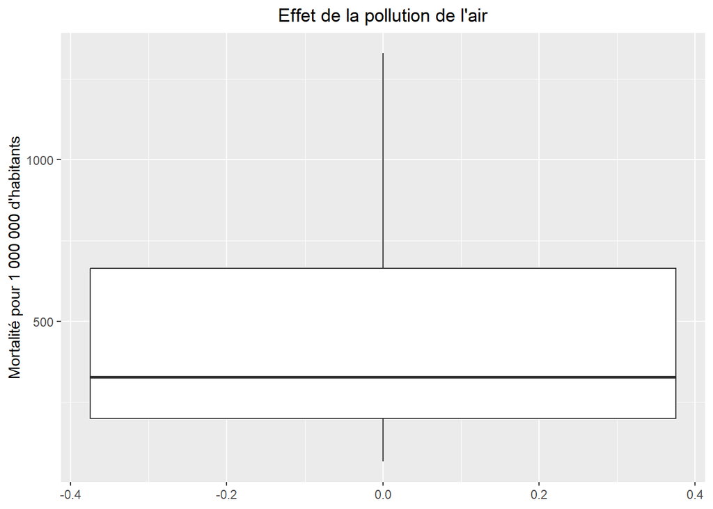

```r
ggplot(data=modele, aes(x=pollution)) +
  geom_boxplot(outlier.colour="red", outlier.shape=8,outlier.size=4)+
  labs(title="Effet de la pollution de l'air",x="Mortalité pour 1 000 000 d'habitants")+
  theme(plot.title = element_text(hjust=0.5))+
  coord_flip()
```

```r
homi <- ggplot(data=modele, aes(x=homicide)) +
  geom_boxplot(outlier.colour="red", outlier.shape=8,outlier.size=4)+
  labs(title="Taux d'homicides intentionnels par pays",x="Homicides intentionnels")+
  theme(plot.title = element_text(hjust=0.5))+
  coord_flip()
```

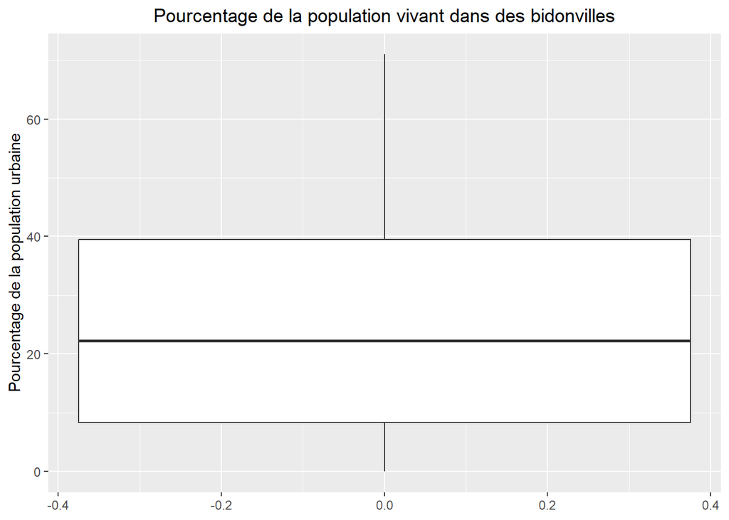

```r
ggplot(data=modele, aes(x=bidonvilles)) +
  geom_boxplot(outlier.colour="red", outlier.shape=8,outlier.size=4)+
  labs(title="Pourcentage de la population vivant dans des bidonvilles",x="Pourcentage de la population urbaine")+
  theme(plot.title = element_text(hjust=0.5))+
  coord_flip()
```

La distribution de la variable bidonvilles est très hétérogène. Aucune tendance n’est vraiment marquée, toutefois, nous observons une disparité très importante entre les pays. Au sein de notre de base de données, nous avons des pays avec des niveaux de développement différents. C’est pourquoi ce graphique nous montre une médiane assez élévée. En effet, en moyenne, plus de 20% de la population urbaine vit dans des bidonvilles dans les pays de notre étude.

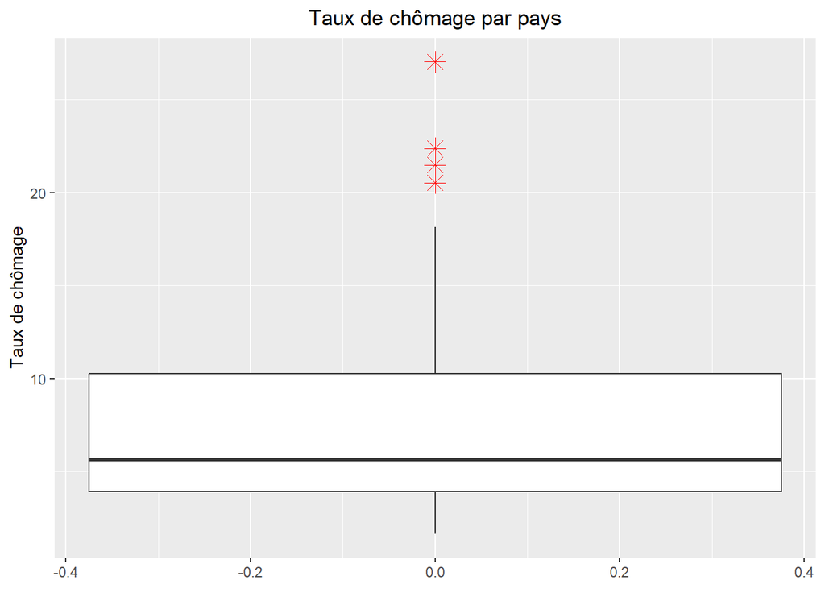

```r
ggplot(data=modele, aes(x=chomage)) +
  geom_boxplot(outlier.colour="red", outlier.shape=8,outlier.size=4)+
  labs(title="Taux de chômage par pays",x="Taux de chômage")+
  theme(plot.title = element_text(hjust=0.5))+
  coord_flip()
```

La majorité des pays voit a un taux de chômage comprix entre 0 et 10%. Nous observons tout de même quelques valeurs aberrantes présentant un taux de chômage particulièrement élevé. En effet, celui-ci peut grimper jusqu’à plus de 25%.

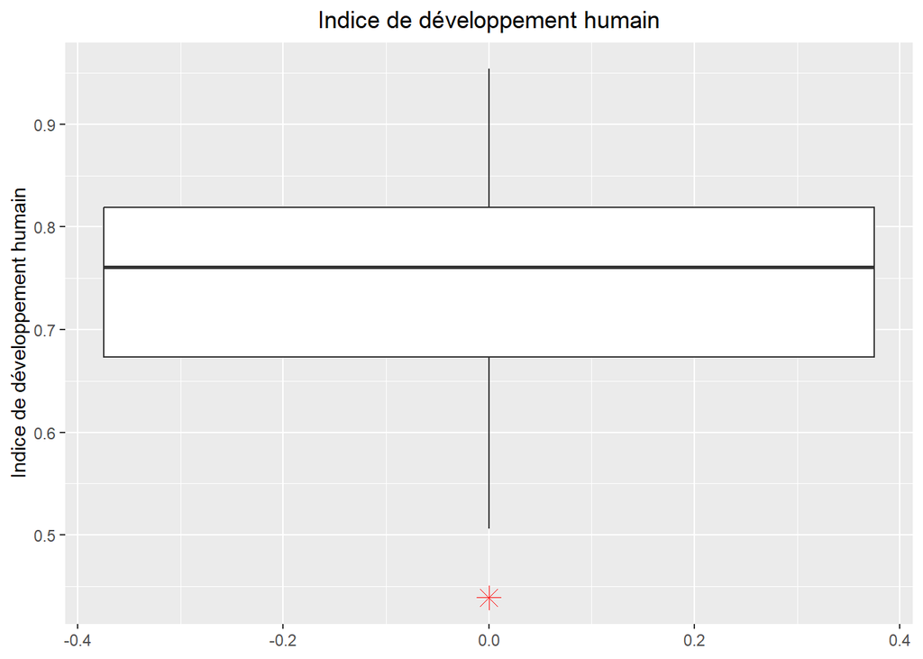

```r
ggplot(data=modele, aes(x=IDH)) +
  geom_boxplot(outlier.colour="red", outlier.shape=8,outlier.size=4)+
  labs(title="Indice de développement humain",x="Indice de développement humain")+
  theme(plot.title = element_text(hjust=0.5))+
  coord_flip()
```

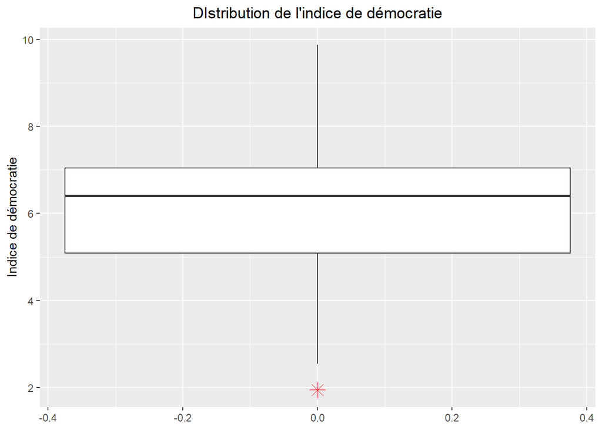

```r
ggplot(data=modele, aes(x=democratie)) +
  geom_boxplot(outlier.colour="red", outlier.shape=8,outlier.size=4)+
  labs(title="DIstribution de l'indice de démocratie",x="Indice de démocratie")+
  theme(plot.title = element_text(hjust=0.5))+
  coord_flip()
```

Ce graphique nous permet de faire la même conclusion. En effet, l’indice de démocratie est assez hétérogène selon les pays et nous avons toujours une valeur atypique.

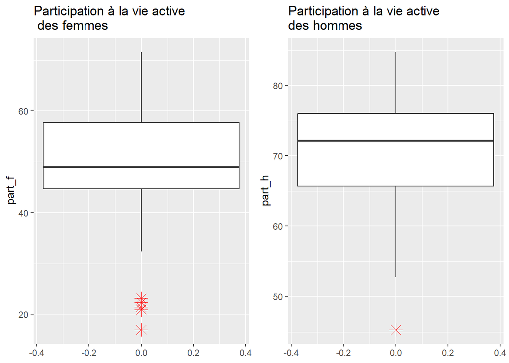

```r
f <- ggplot(data=modele, aes(x=part_f)) +
  geom_boxplot(outlier.colour="red", outlier.shape=8,
                outlier.size=4)+
  labs(title="Participation à la vie active \n des femmes")+
  coord_flip()

h <- ggplot(data=modele, aes(x=part_h)) +
  geom_boxplot(outlier.colour="red", outlier.shape=8,
                outlier.size=4)+
  labs(title="Participation à la vie active \ndes hommes")+
  coord_flip()

grid.arrange(f, h, ncol=2)
```

```r
popu <- ggplot(data=modele, aes(x=pop)) +
  geom_boxplot(outlier.colour="red", outlier.shape=8,outlier.size=4)+
  labs(title="Distribution de la population",x="Population (en milliers)")+
  theme(plot.title = element_text(hjust=0.5))+
  coord_flip()
```

Ce graphique nous présente la ditribution de la variable population, nous pouvons observer une très grande variabilité du fait de l’hétérogénité de nos individus.

```r
espe <- ggplot(data=modele, aes(x=esperance)) +
  geom_boxplot(outlier.colour="red", outlier.shape=8,outlier.size=4)+
  labs(title="Distribution de l'esperance de vie",x="Espérance de vie")+
  theme(plot.title = element_text(hjust=0.5))+
  coord_flip()
```

Sur ce graphique nous pouvons observer la concentration de la variable espérance de vie autour de 75 ans. Cependant nous observons tout de même de nombreuses valeurs atypiques inférieures à 65 ans.

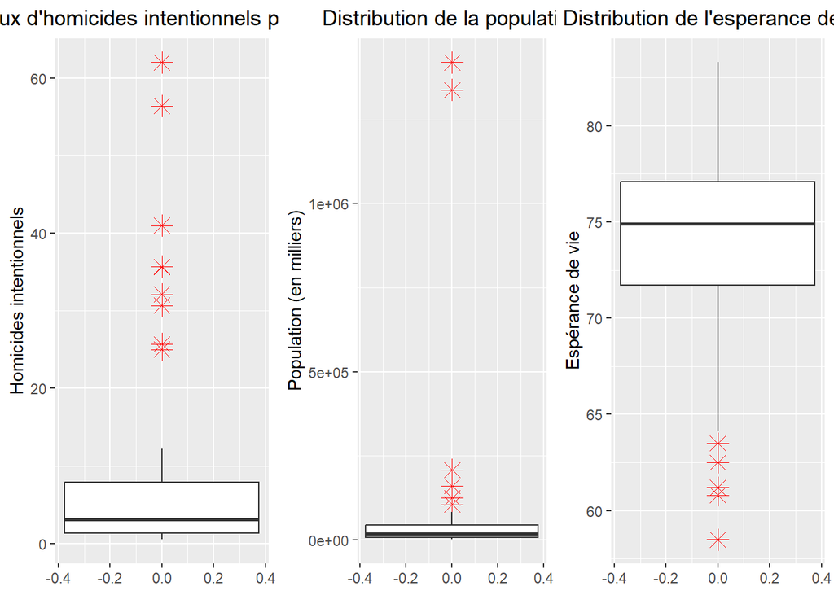

```r
grid.arrange(homi, popu,espe, ncol=3)
```

```r
tab_explication <- data.frame(matrix(0,ncol=2,nrow=2),row.names=c("Non","Oui"))
colnames(tab_explication) <- c("Non","Oui")
tab_explication$Non <- c("Interdit","Totalement autorisé")
tab_explication$Oui <- c("Autorisé sous-conditions","-")
knitr::kable(tab_explication)
```

|  | Non | Oui |
| --- | --- | --- |
| Non | Interdit | Autorisé sous-conditions |
| Oui | Totalement autorisé | - |

```r
tab <- table(modele[c(15,16)])/nrow(modele)
knitr::kable(tab, row.names(c(0, 1)), col.names = c(0,1), caption = "Tableau de fréquence des conditons d'autorisation de l'avortement")
```

Tableau de fréquence des conditons d’autorisation de l’avortement

|  | 0 | 1 |
| --- | --- | --- |
| 0 | 0.2631579 | 0.2631579 |
| 1 | 0.4736842 | 0.0000000 |

Ce tableau de fréquence nous permet de faire apparaître les effectifs de chacune des modalités de nos variables indicatrices. Nous pouvons alors observer une majorité de pays autorisant l’avortement sans condition, 27 au total ce qui représente 47% de nos individus. 26% l’autorisent sous condition et 26% l’interdisent totalement. Nous avons donc au sein de notre modèle des pays ayant des moeurs différents ainsi qu’une avancé du droit des femmes inégale.

## Matrice de corrélation : corrélations avec la variable dépendante et corrélations entres les variables explicatives

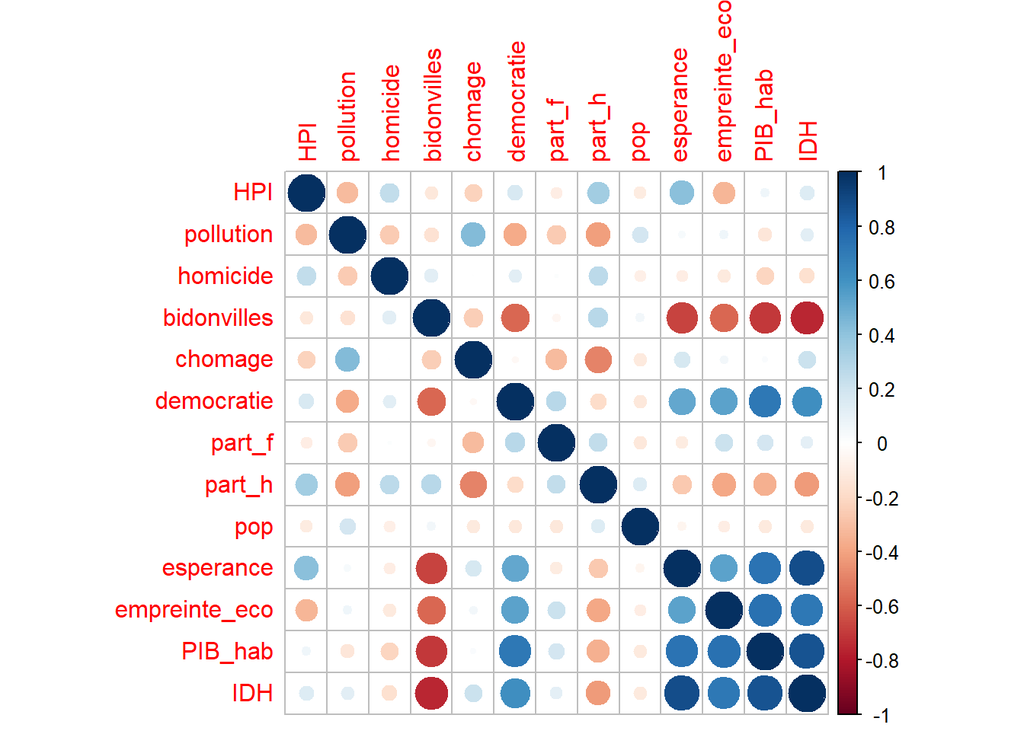

```r
corrplot(cor(modele[-c(1,2,15,16)]),method="circle")
```

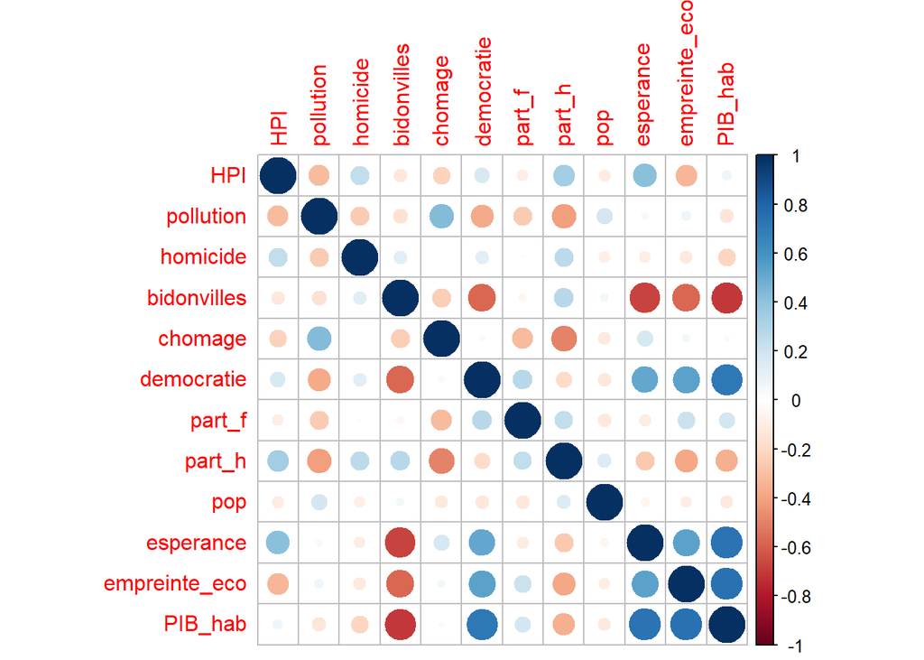

```r
# Après avoir enlevé les variables corrélées
corrplot(cor(modele[-c(1,2,15,16,17)]),method="circle")
```

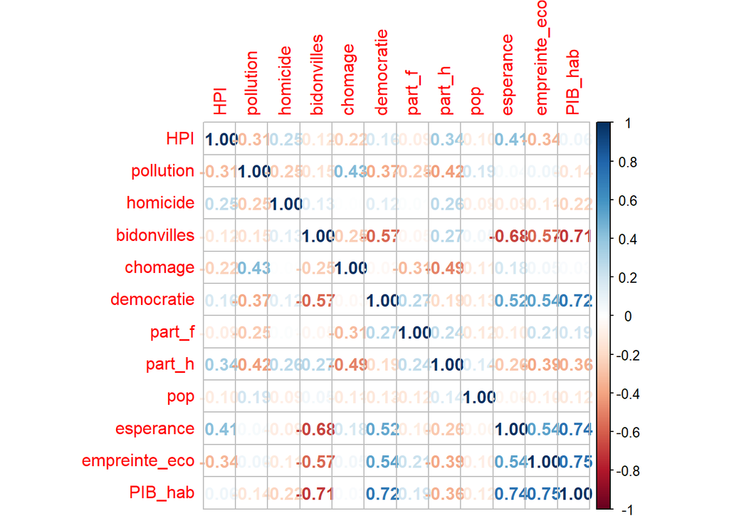

```r
corrplot(cor(modele[-c(1,2,15,16,17)]),method="number")
```

Après avoir réalisé la matrice de corrélation, on observe une forte corrélation avec la variable IDGH. Nous allons donc la supprimer pour continuer l’étude en toute cohérence. Ainsi, nous avons donc 13 variables au lieu de 14.

## Régression sur le modèle initial à 13 variables

```r
reg <- lm(HPI~pollution+homicide+bidonvilles+chomage+democratie+part_f+part_h+pop+esperance+empreinte_eco+PIB_hab+avortement_autorise+avortement_sous_conditions,data=modele)

# Description des résultats
# summary(reg)
stargazer(reg,type="text",title="Résultats de la régression sur le modèle initial à 13 variables explicatives",out="regression1.txt")
```

```
##
## Résultats de la régression sur le modèle initial à 13 variables explicatives
## =======================================================
##                                 Dependent variable:
##                             ---------------------------
##                                         HPI
## -------------------------------------------------------
## pollution                             -0.002
##                                       (0.003)
##
## homicide                             0.142***
##                                       (0.044)
##
## bidonvilles                           -0.031
##                                       (0.046)
##
## chomage                              -0.449***
##                                       (0.113)
##
## democratie                             0.294
##                                       (0.526)
##
## part_f                                -0.035
##                                       (0.050)
##
## part_h                                 0.123
##                                       (0.098)
##
## pop                                 -0.00000**
##                                      (0.00000)
##
## esperance                            1.166***
##                                       (0.144)
##
## empreinte_eco                        -3.521***
##                                       (0.423)
##
## PIB_hab                              -0.00002
##                                      (0.0001)
##
## avortement_autorise1                  3.598*
##                                       (1.990)
##
## avortement_sous_conditions1           2.880*
##                                       (1.588)
##
## Constant                             -34.670**
##                                      (13.583)
##
## -------------------------------------------------------
## Observations                            57
## R2                                     0.840
## Adjusted R2                            0.791
## Residual Std. Error               3.539 (df = 43)
## F Statistic                   17.304*** (df = 13; 43)
## =======================================================
## Note:                       *p<0.1; **p<0.05; ***p<0.01
```

## Causalité avec la variable endogène

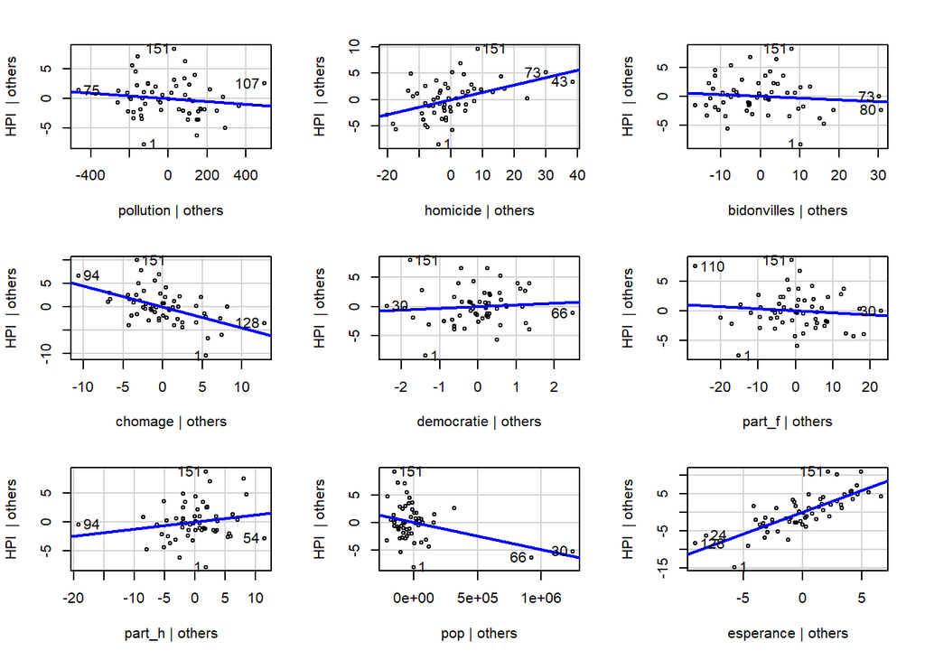

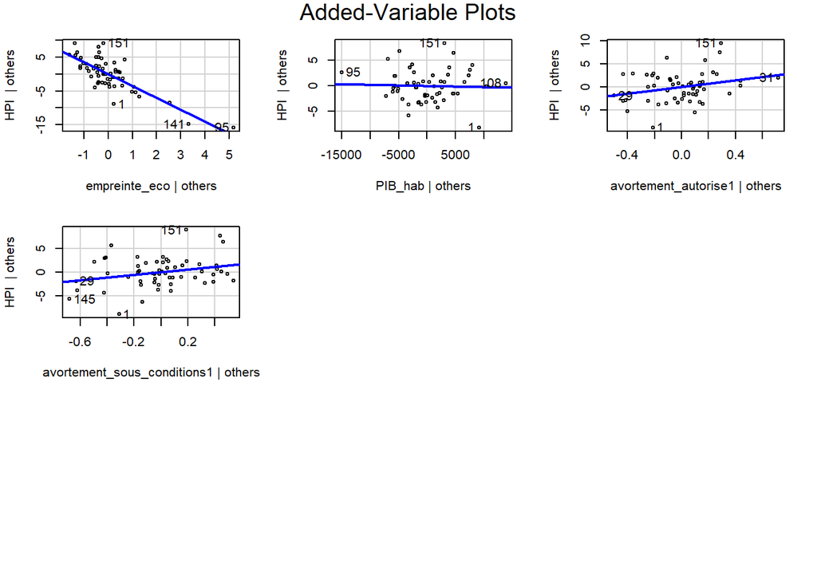

```r
#coef(reg) # affiche les coefficients de la droite
#residuals(reg) # donne les résidus
avPlots(reg) # représente les relations de chacune des variables
```

On observe plusieurs individus atypiques dans les nuages de points : 1, 30, 66, 73, 94, 151. Nous allons les identifier dans notre rapport final. On observe aucune forme particulière dans les relations entre la variable endogène et les variables explicatives (avPlots). Ce constat nous permet de conclure que nous n’avons pas besoin de transformer nos variables.

# Justifier la spécification du modèle

```r
# VIF
vif(reg)
```

```
##                  pollution                   homicide
##                   3.106080                   1.696063
##                bidonvilles                    chomage
##                   3.613879                   1.965906
##                 democratie                     part_f
##                   3.406303                   1.918501
##                     part_h                        pop
##                   2.648425                   1.199696
##                  esperance              empreinte_eco
##                   3.212433                   2.696530
##                    PIB_hab        avortement_autorise
##                   8.265985                   4.492900
## avortement_sous_conditions
##                   2.225966
```

```r
sqrt(vif(reg))
```

```
##                  pollution                   homicide
##                   1.762407                   1.302330
##                bidonvilles                    chomage
##                   1.901021                   1.402108
##                 democratie                     part_f
##                   1.845617                   1.385100
##                     part_h                        pop
##                   1.627398                   1.095306
##                  esperance              empreinte_eco
##                   1.792326                   1.642111
##                    PIB_hab        avortement_autorise
##                   2.875063                   2.119646
## avortement_sous_conditions
##                   1.491967
```

```r
# Règle de Klein
cor(modele[-c(1,2,15,16,17)])^2 > summary(reg)$r.squared
```

```
##                 HPI pollution homicide bidonvilles chomage democratie part_f
## HPI            TRUE     FALSE    FALSE       FALSE   FALSE      FALSE  FALSE
## pollution     FALSE      TRUE    FALSE       FALSE   FALSE      FALSE  FALSE
## homicide      FALSE     FALSE     TRUE       FALSE   FALSE      FALSE  FALSE
## bidonvilles   FALSE     FALSE    FALSE        TRUE   FALSE      FALSE  FALSE
## chomage       FALSE     FALSE    FALSE       FALSE    TRUE      FALSE  FALSE
## democratie    FALSE     FALSE    FALSE       FALSE   FALSE       TRUE  FALSE
## part_f        FALSE     FALSE    FALSE       FALSE   FALSE      FALSE   TRUE
## part_h        FALSE     FALSE    FALSE       FALSE   FALSE      FALSE  FALSE
## pop           FALSE     FALSE    FALSE       FALSE   FALSE      FALSE  FALSE
## esperance     FALSE     FALSE    FALSE       FALSE   FALSE      FALSE  FALSE
## empreinte_eco FALSE     FALSE    FALSE       FALSE   FALSE      FALSE  FALSE
## PIB_hab       FALSE     FALSE    FALSE       FALSE   FALSE      FALSE  FALSE
##               part_h   pop esperance empreinte_eco PIB_hab
## HPI            FALSE FALSE     FALSE         FALSE   FALSE
## pollution      FALSE FALSE     FALSE         FALSE   FALSE
## homicide       FALSE FALSE     FALSE         FALSE   FALSE
## bidonvilles    FALSE FALSE     FALSE         FALSE   FALSE
## chomage        FALSE FALSE     FALSE         FALSE   FALSE
## democratie     FALSE FALSE     FALSE         FALSE   FALSE
## part_f         FALSE FALSE     FALSE         FALSE   FALSE
## part_h          TRUE FALSE     FALSE         FALSE   FALSE
## pop            FALSE  TRUE     FALSE         FALSE   FALSE
## esperance      FALSE FALSE      TRUE         FALSE   FALSE
## empreinte_eco  FALSE FALSE     FALSE          TRUE   FALSE
## PIB_hab        FALSE FALSE     FALSE         FALSE    TRUE
```

Le VIF nous permet de voir qu’il n’existe pas de multicolinéarité car aucune valeur n’est au-dessus de 10. Le modèle est donc globalement fiable. Dans notre cas, l’écart-type du coefficient de la variable PIB par habitant est 2.87 plus grand qu’il ne le serait si le PIB par habitant n’était pas corrélée aux autres variables de notre modèle. De plus, la Règle de Klein nous permet de conclure qu’il n’existe pas de problème de colinéarité.

# 4. Estimation du modèle

## Critère de l’AIC

```r
# estimation du modèle complet
modele_complet <- lm(HPI ~ pollution+homicide+bidonvilles+chomage+democratie+part_f+part_h+pop+esperance+empreinte_eco+PIB_hab+avortement_autorise+avortement_sous_conditions, data = modele)


# Backward regression model
modele_backward <- stepAIC(modele_complet, direction = "backward",
                      trace = FALSE)
stargazer(modele_backward,type="text",title="Résultats de la régression du modèle backward")
```

```
##
## Résultats de la régression du modèle backward
## =======================================================
##                                 Dependent variable:
##                             ---------------------------
##                                         HPI
## -------------------------------------------------------
## pollution                             -0.003
##                                       (0.002)
##
## homicide                             0.157***
##                                       (0.039)
##
## chomage                              -0.454***
##                                       (0.096)
##
## pop                                 -0.00000**
##                                      (0.00000)
##
## esperance                            1.249***
##                                       (0.098)
##
## empreinte_eco                        -3.579***
##                                       (0.337)
##
## avortement_autorise1                  2.869*
##                                       (1.607)
##
## avortement_sous_conditions1           3.257**
##                                       (1.439)
##
## Constant                            -32.792***
##                                       (7.023)
##
## -------------------------------------------------------
## Observations                            57
## R2                                     0.829
## Adjusted R2                            0.800
## Residual Std. Error               3.458 (df = 48)
## F Statistic                   29.084*** (df = 8; 48)
## =======================================================
## Note:                       *p<0.1; **p<0.05; ***p<0.01
```

```r
# forward regression model
modele_forward <- stepAIC(modele_complet, direction = "forward",
                      trace = FALSE)
stargazer(modele_forward,type="text",title="Résultats de la régression du modèle forward")
```

```
##
## Résultats de la régression du modèle forward
## =======================================================
##                                 Dependent variable:
##                             ---------------------------
##                                         HPI
## -------------------------------------------------------
## pollution                             -0.002
##                                       (0.003)
##
## homicide                             0.142***
##                                       (0.044)
##
## bidonvilles                           -0.031
##                                       (0.046)
##
## chomage                              -0.449***
##                                       (0.113)
##
## democratie                             0.294
##                                       (0.526)
##
## part_f                                -0.035
##                                       (0.050)
##
## part_h                                 0.123
##                                       (0.098)
##
## pop                                 -0.00000**
##                                      (0.00000)
##
## esperance                            1.166***
##                                       (0.144)
##
## empreinte_eco                        -3.521***
##                                       (0.423)
##
## PIB_hab                              -0.00002
##                                      (0.0001)
##
## avortement_autorise1                  3.598*
##                                       (1.990)
##
## avortement_sous_conditions1           2.880*
##                                       (1.588)
##
## Constant                             -34.670**
##                                      (13.583)
##
## -------------------------------------------------------
## Observations                            57
## R2                                     0.840
## Adjusted R2                            0.791
## Residual Std. Error               3.539 (df = 43)
## F Statistic                   17.304*** (df = 13; 43)
## =======================================================
## Note:                       *p<0.1; **p<0.05; ***p<0.01
```

```r
# Stepwise regression model
modele_both <- stepAIC(modele_complet, direction = "both",
                      trace = FALSE)
modele_both$anova
```

```
## Stepwise Model Path
## Analysis of Deviance Table
##
## Initial Model:
## HPI ~ pollution + homicide + bidonvilles + chomage + democratie +
##     part_f + part_h + pop + esperance + empreinte_eco + PIB_hab +
##     avortement_autorise + avortement_sous_conditions
##
## Final Model:
## HPI ~ pollution + homicide + chomage + pop + esperance + empreinte_eco +
##     avortement_autorise + avortement_sous_conditions
##
##
##            Step Df   Deviance Resid. Df Resid. Dev      AIC
## 1                                    43   538.5395 156.0111
## 2     - PIB_hab  1  0.7188314        44   539.2584 154.0872
## 3  - democratie  1  3.2946550        45   542.5530 152.4344
## 4      - part_f  1  4.2925103        46   546.8455 150.8836
## 5 - bidonvilles  1  9.6151821        47   556.4607 149.8771
## 6      - part_h  1 17.4690638        48   573.9298 149.6390
```

```r
stargazer(modele_both,type="text",title="Résultats de la régression du modèle stepwise")
```

```
##
## Résultats de la régression du modèle stepwise
## =======================================================
##                                 Dependent variable:
##                             ---------------------------
##                                         HPI
## -------------------------------------------------------
## pollution                             -0.003
##                                       (0.002)
##
## homicide                             0.157***
##                                       (0.039)
##
## chomage                              -0.454***
##                                       (0.096)
##
## pop                                 -0.00000**
##                                      (0.00000)
##
## esperance                            1.249***
##                                       (0.098)
##
## empreinte_eco                        -3.579***
##                                       (0.337)
##
## avortement_autorise1                  2.869*
##                                       (1.607)
##
## avortement_sous_conditions1           3.257**
##                                       (1.439)
##
## Constant                            -32.792***
##                                       (7.023)
##
## -------------------------------------------------------
## Observations                            57
## R2                                     0.829
## Adjusted R2                            0.800
## Residual Std. Error               3.458 (df = 48)
## F Statistic                   29.084*** (df = 8; 48)
## =======================================================
## Note:                       *p<0.1; **p<0.05; ***p<0.01
```

Le modèle retenu est: HPI~pollution+homicide+chomage+pop+esperance+empreinte_eco+avortement_aut+avortement_cond

```r
# création du dataframe réduit : après l'AIC
modele_reduit <- modele[c(3:5,7,11:13,15,16)]
stargazer(modele_reduit,type="text")
```

```
##
## =============================================================
## Statistic     N     Mean     St. Dev.     Min        Max
## -------------------------------------------------------------
## HPI           57   47.298      7.741    27.021     64.166
## pollution     57  452.276     315.568   66.438    1,330.188
## homicide      57   9.143      13.933     0.529     62.021
## chomage       57   7.947       5.851     1.644     27.040
## pop           57 80,519.210 254,305.400 627.563 1,421,022.000
## esperance     57   73.961      5.884    58.500     83.300
## empreinte_eco 57   3.006       1.835     0.664      8.227
## -------------------------------------------------------------
```

Nous réalisons un résumé statistique des variables utilisées dans notre modèle après sélection selon le critère de l’AIC.

## Détection hétéroscédasticité

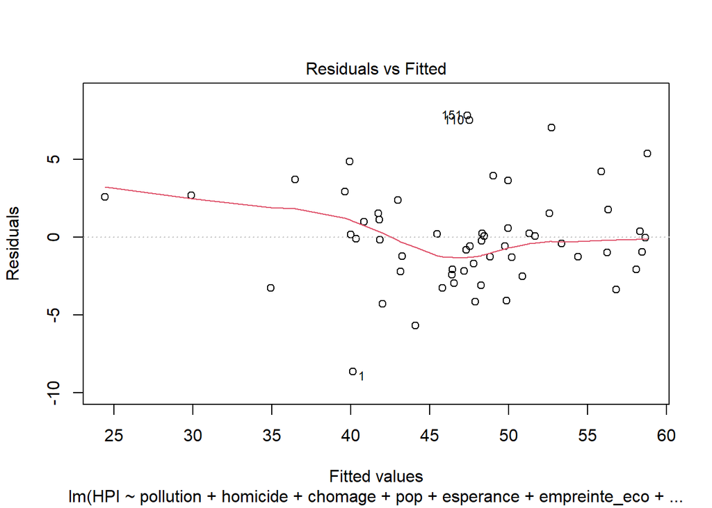

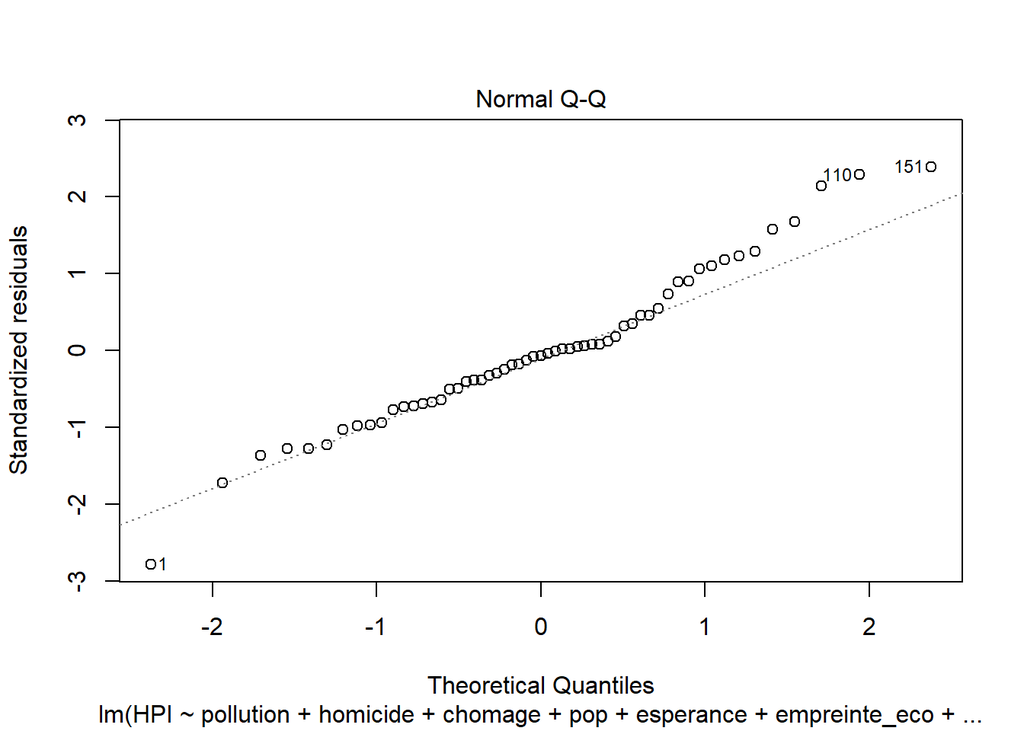

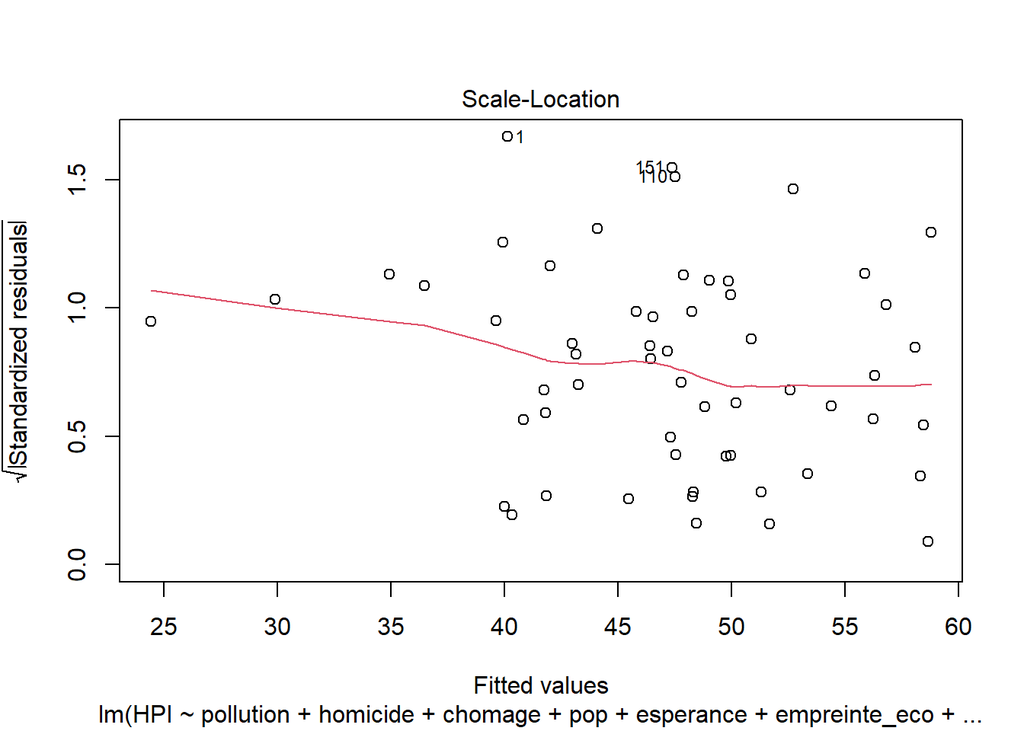

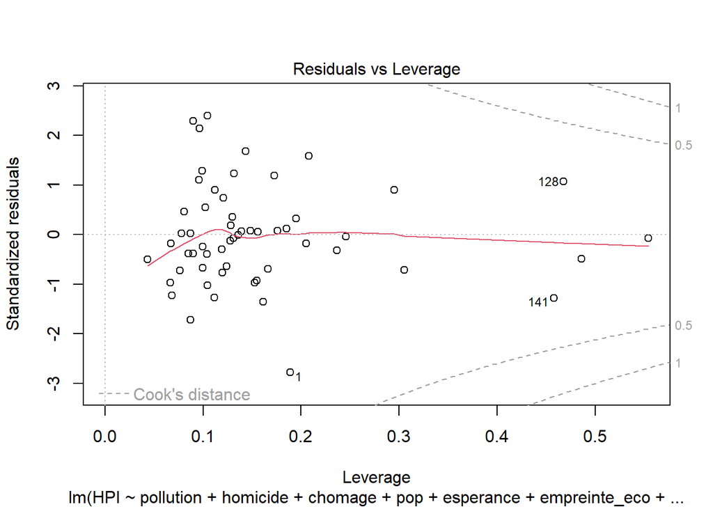

```r
# test de normalité des résidus
plot(modele_both)
```

```r
stargazer(modele_both)
```

[output not shown]

```r
stargazer(modele_both,type="text",title="Représentation du modèle choisi",out="modele_both.txt")
```

```
##
## Représentation du modèle choisi
## =======================================================
##                                 Dependent variable:
##                             ---------------------------
##                                         HPI
## -------------------------------------------------------
## pollution                             -0.003
##                                       (0.002)
##
## homicide                             0.157***
##                                       (0.039)
##
## chomage                              -0.454***
##                                       (0.096)
##
## pop                                 -0.00000**
##                                      (0.00000)
##
## esperance                            1.249***
##                                       (0.098)
##
## empreinte_eco                        -3.579***
##                                       (0.337)
##
## avortement_autorise1                  2.869*
##                                       (1.607)
##
## avortement_sous_conditions1           3.257**
##                                       (1.439)
##
## Constant                            -32.792***
##                                       (7.023)
##
## -------------------------------------------------------
## Observations                            57
## R2                                     0.829
## Adjusted R2                            0.800
## Residual Std. Error               3.458 (df = 48)
## F Statistic                   29.084*** (df = 8; 48)
## =======================================================
## Note:                       *p<0.1; **p<0.05; ***p<0.01
```

Nous avons une distribution aléatoire des résidus, traduisant une relation linéaire du modèle. Le QQplot nous permet de vérifier ou non la normalité des résidus. Le résultat n’étant pas concluant puisque certains points sont éloignés de la droite, nous allons effectuer un test de Shapiro-Wilk. Le graphique “residuals vs fitted” nous permet de montrer s’il y a un problème d’hétéroscédasticité. Dans notre cas, les résidus sont concentrés à droite, ce qui peut être synonyme d’hétéroscédasticité.

```r
shapiro.test(residuals(modele_both))
```

```
##
##  Shapiro-Wilk normality test
##
## data:  residuals(modele_both)
## W = 0.97406, p-value = 0.2577
```

Le test de Shapiro a une p-value de 0.2577 > 0.05. On ne rejette pas H0, les résidus sont normaux.

## Analyse des résidus

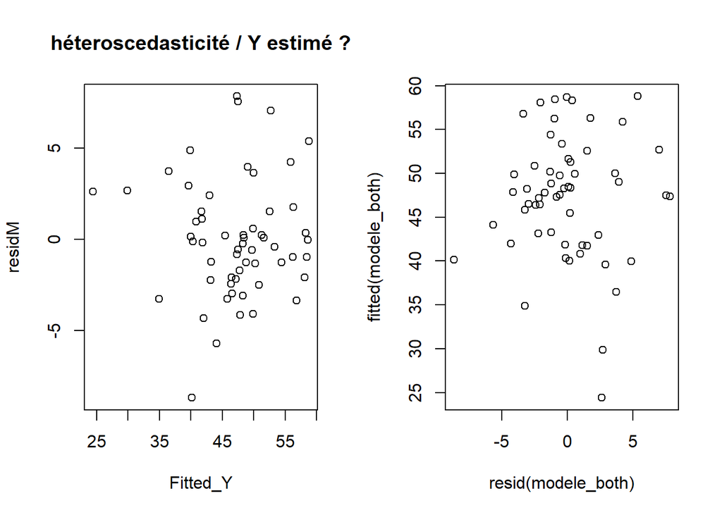

```r
residM = residuals(modele_both)
residM2 = residM^2
Fitted_Y = fitted(modele_both)


par(mfrow=c(1,2))
#graphique des résidus
#détection graphique des résidus
plot(residM~Fitted_Y, data=modele_reduit, main="héteroscedasticité / Y estimé ?" )
#OU
plot(resid(modele_both),fitted(modele_both))
```

## Test homoscédasticité

L’hypothèse d’homoscédasticité requiert que la variance des termes d’erreur soit la même pour chaque observation

```r
bptest(modele_both)
```

```
##
##  studentized Breusch-Pagan test
##
## data:  modele_both
## BP = 9.7756, df = 8, p-value = 0.2811
```

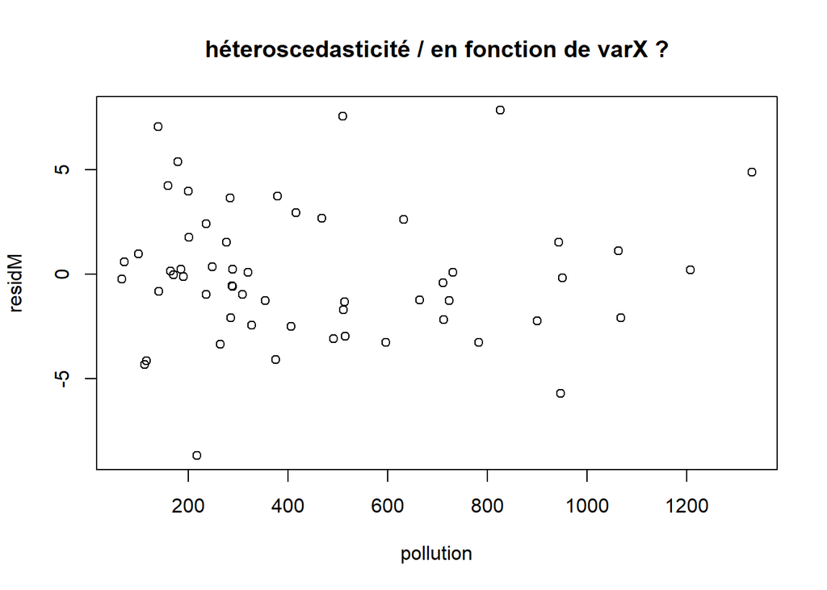

```r
plot(residM~pollution, data=modele_reduit, main="héteroscedasticité / en fonction de varX ?" )
```

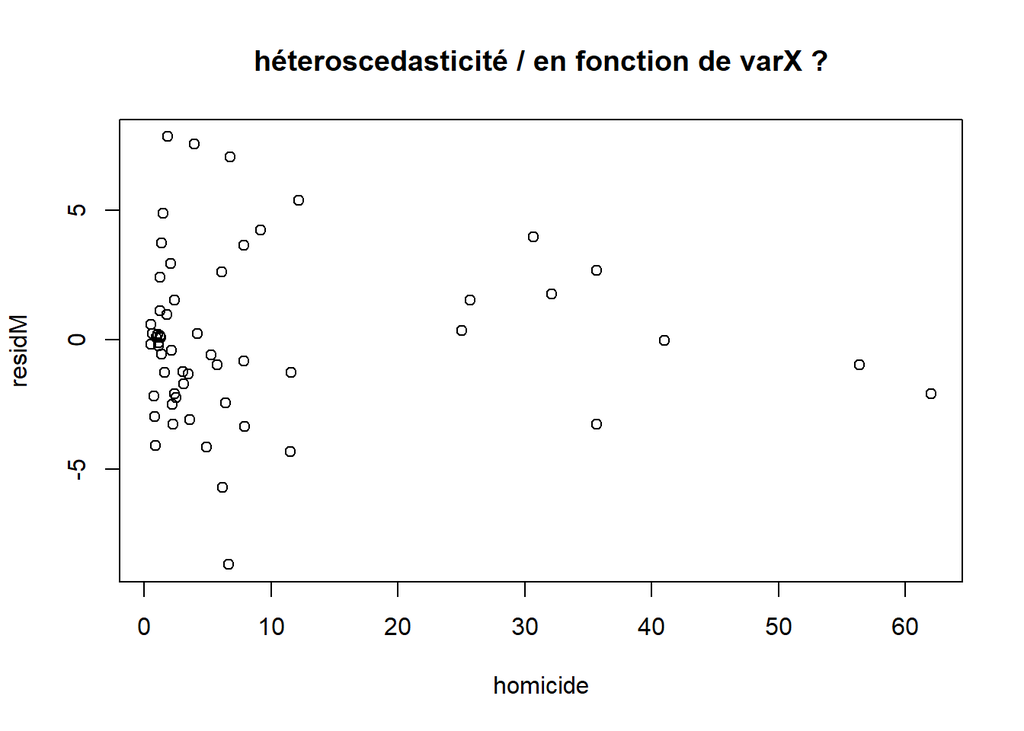

```r
plot(residM~homicide, data=modele_reduit, main="héteroscedasticité / en fonction de varX ?" )
```

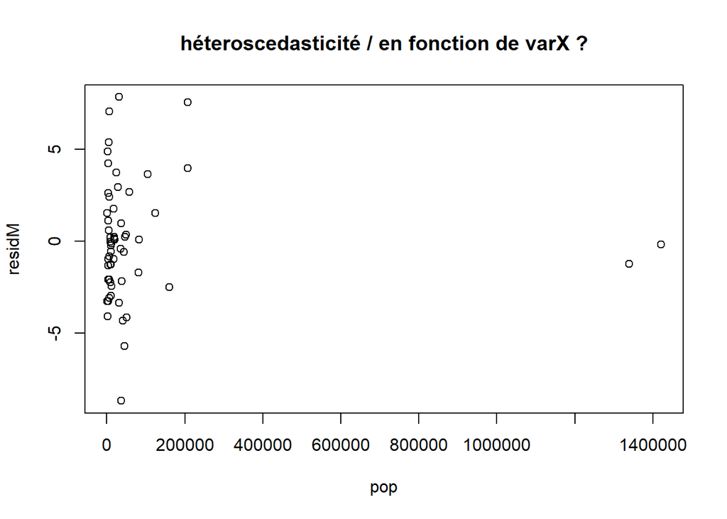

```r
plot(residM~pop, data=modele_reduit, main="héteroscedasticité / en fonction de varX ?" )
```

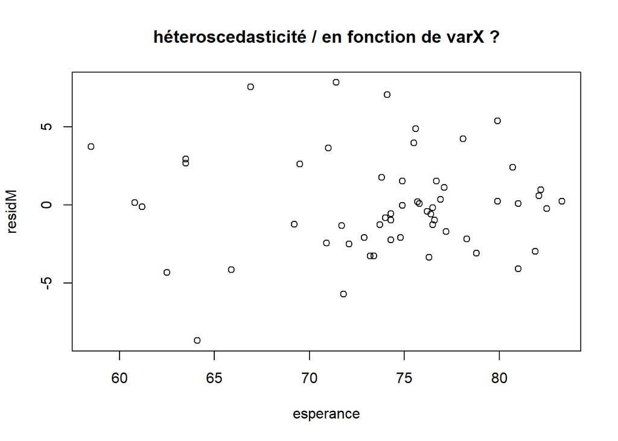

```r
plot(residM~esperance, data=modele_reduit, main="héteroscedasticité / en fonction de varX ?" )
```

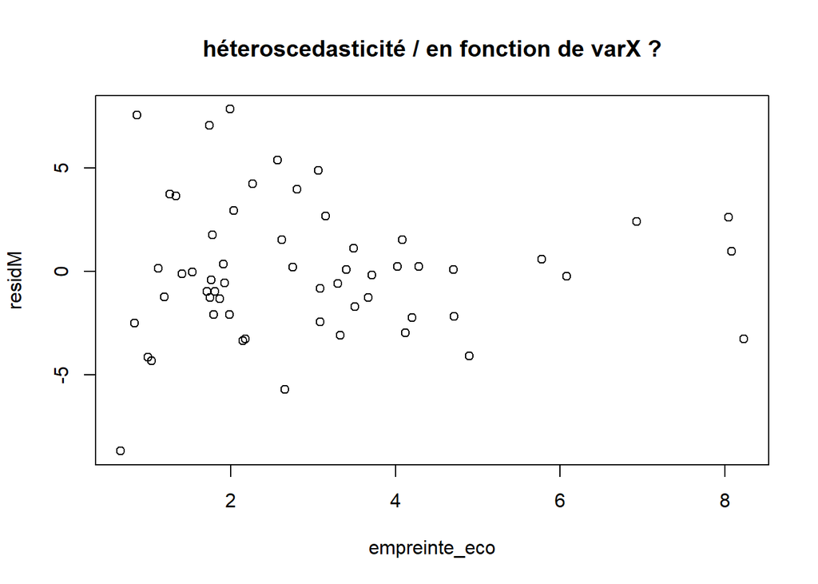

```r
plot(residM~empreinte_eco, data=modele_reduit, main="héteroscedasticité / en fonction de varX ?" )
```

Test de Goldfen-Quandt

```r
gqtest(modele_both, order.by = ~homicide+chomage+pop+esperance+empreinte_eco+avortement_autorise+avortement_sous_conditions, data=modele_reduit, fraction=9)
```

```
##
##  Goldfeld-Quandt test
##
## data:  modele_both
## GQ = 2.6261, df1 = 15, df2 = 15, p-value = 0.0355
## alternative hypothesis: variance increases from segment 1 to 2
```